# Lameness Data Analysis Report

Marshall Region

Author

Gerard Cramer

Published

February 14, 2025

[figure not shown]

# Introduction

This is a summary of the hoof trimming and lesions data from Dec 2022 to Nov 2024. Historical data was used starting from 2018 was used to determine the lesion history of cows trimmed in the last year.

Of note in this report you will at times see the data split out into the following categories:

- *All Cases:*
  - Includes all occurrences of a lesion.
  - A cow could have had the lesion once or 5 times in the past year and all them are included.
  - This category is important as it shows how many lame cows the go through the chute.
- *First Cases:*
  - Includes only cows that had a lesion for the first time in the past year.
  - I consider this category the most important category as it tells us how many lame cows we are creating.
  - The difference between *first cases* and *all cases* paints a picture of the number of chronic cows.
- *Second Cases:*
  - Includes only cows that had a lesion for the second time in the past year.
  - This category includes cows that will eventually become chronic cows but also some cows that might just have needed a bit more time to heel.
  - Three or more cases:
    - Includes cows that had a lesion three or more times in the past year.
    - These are the chronic cows and once we need to manage appropriately.
- *Graphs and Tables:*
  - Tables and figures will be broken down by lactation group, months, or across DIM categories.
  - Most figures are survival curves and have % of cows still alive on the *y-axis* and time since the lesion on the *x-axis.* These graphs have different curves to show the difference between cows.
    - In these survival curves, a line closer to the top indicates that cows do better.
    - The shading around lines indicates the precision around the estimate of the line. Typically, if the shading overlaps, we consider the lines similar with no evidence of a difference.

# Timing of Trimming

Figure 1 compares when cows get trimmed in each lactation and their lameness history between farms in Marshall region.

The peaks at dry-off and mid-lactation are expected, considering the trimming program.

Any other peaks indicate times where cows are trimmed due to lameness.

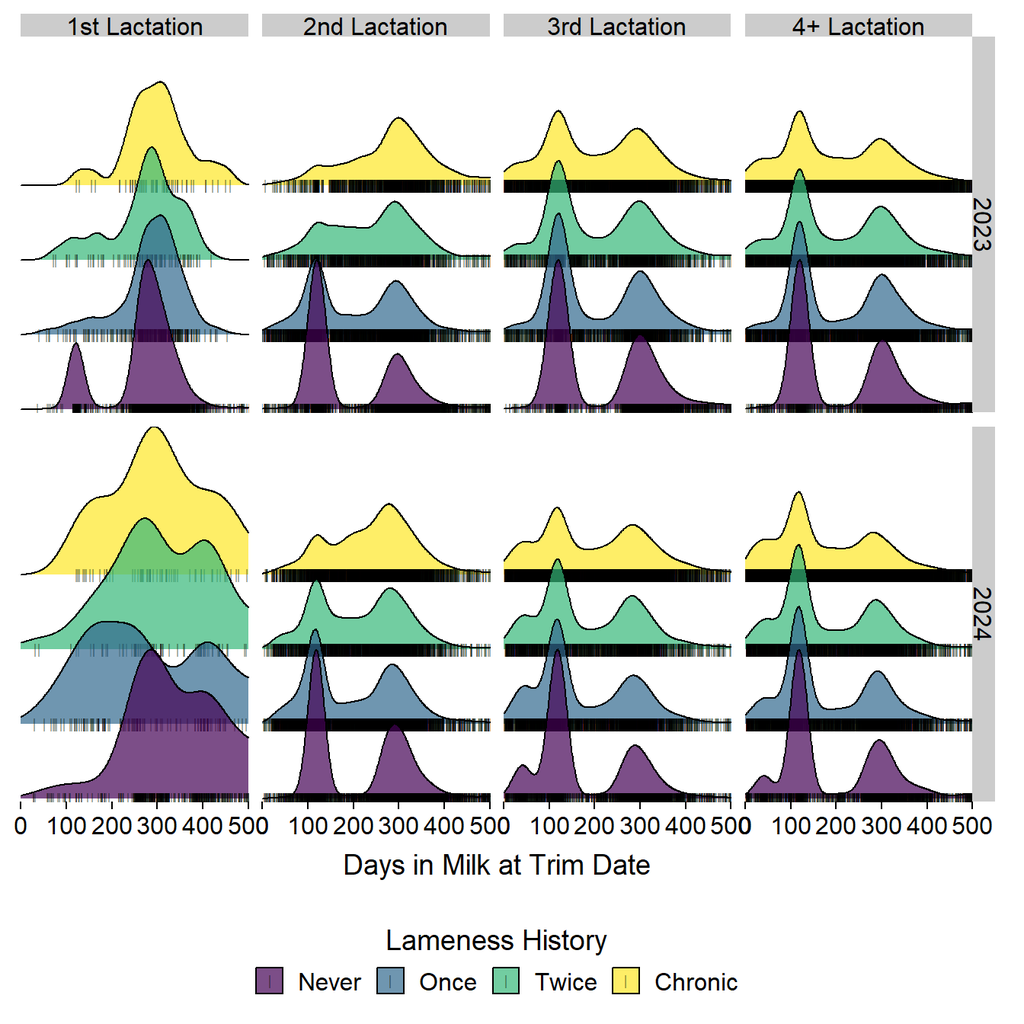

Figure 1: Distribution when trimming happens during lactation. Note: Height of curves are relative to each individual category

# Time to Lesion After a Routine Trimming

Figure 2 shows how soon after regular hoof trimming, cows with **no lesions** **ever** have a hoof trimming with a lesion.

The sharper drop after 150 days likely indicates when cows start to get retrimmed, so lesions would be found in some of them.

We want the lines to stay close to 100% for as long as possible for these graphs.

Sharp drops in the 1st 30 days indicate problems created or missed by trimming.

Drops after 60 days suggest the trimming was at dry-off

Figure 2: The longer and closer the 100% the line the better

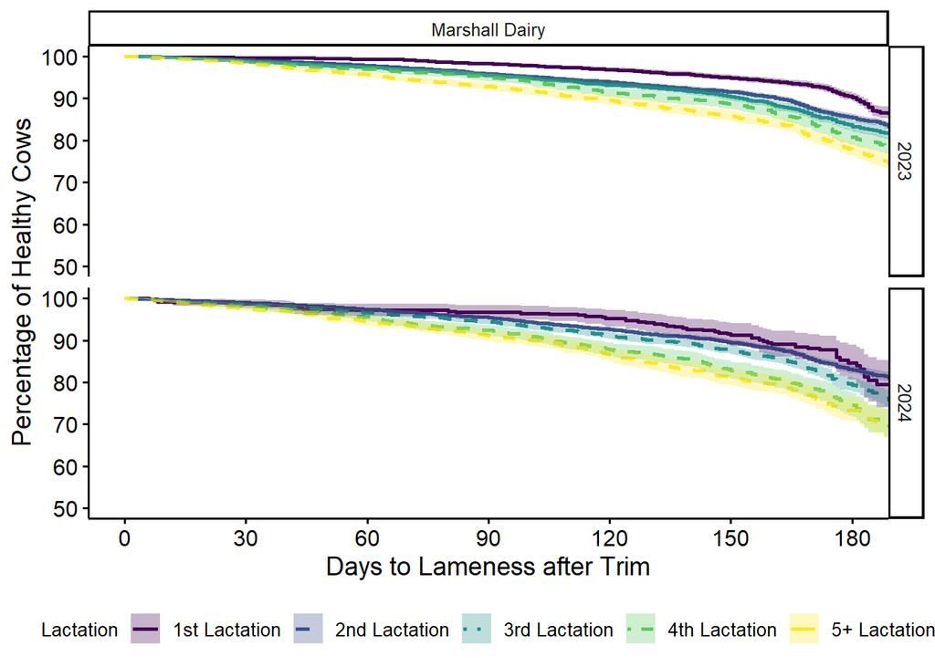

### Tables

Table 1 displays the % of cows in each lactation group with **no history of lesions ever** at trimming that get a lesion-specific time points after that hoof trimming.

Table 1: Time to lameness after routine hoof trimming for each farm at specific time points in each lactation for 2024.

| Farm | % Lame (Confidence Interval) at 30 Days | % Lame (Confidence Interval) at 60 Days | % Lame (Confidence Interval) at 90 Days | % Lame (Confidence Interval) at 180 Days |
| --- | --- | --- | --- | --- |
| Marshall Dairy |  |  |  |  |
| 1 | 1.3% (0.3%, 2.3%) | 2.8% (1.3%, 4.3%) | 3.3% (1.7%, 4.9%) | 15% (11%, 19%) |
| 2 | 1.0% (0.8%, 1.2%) | 2.6% (2.3%, 2.9%) | 4.6% (4.2%, 5.0%) | 17% (16%, 18%) |
| 3 | 1.5% (1.2%, 1.8%) | 3.4% (3.0%, 3.9%) | 5.6% (4.9%, 6.2%) | 21% (19%, 22%) |
| 4 | 2.0% (1.4%, 2.6%) | 4.5% (3.6%, 5.4%) | 7.6% (6.4%, 8.8%) | 25% (23%, 28%) |
| 5+ | 2.4% (1.7%, 3.0%) | 5.6% (4.5%, 6.6%) | 8.8% (7.5%, 10%) | 27% (24%, 29%) |

# Lesion Comparison

The frequency of lesions types for 1st cases and all cases across the farms for Marshall region are shown in figures below

**Year to Year Any Lesion**

Figure 3: Comparision of Lesions between years

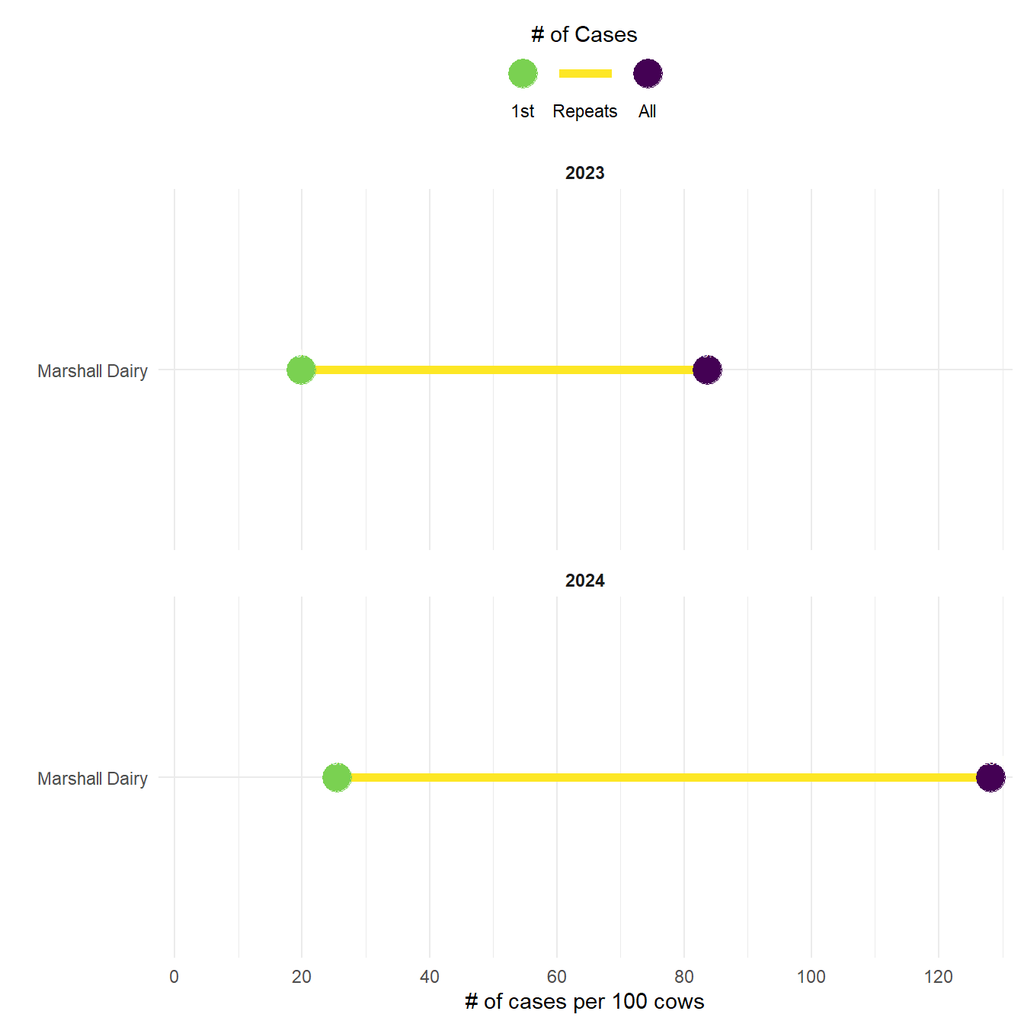

**2024 Lesions**

Figure 4: Comparision of Lesions between farms

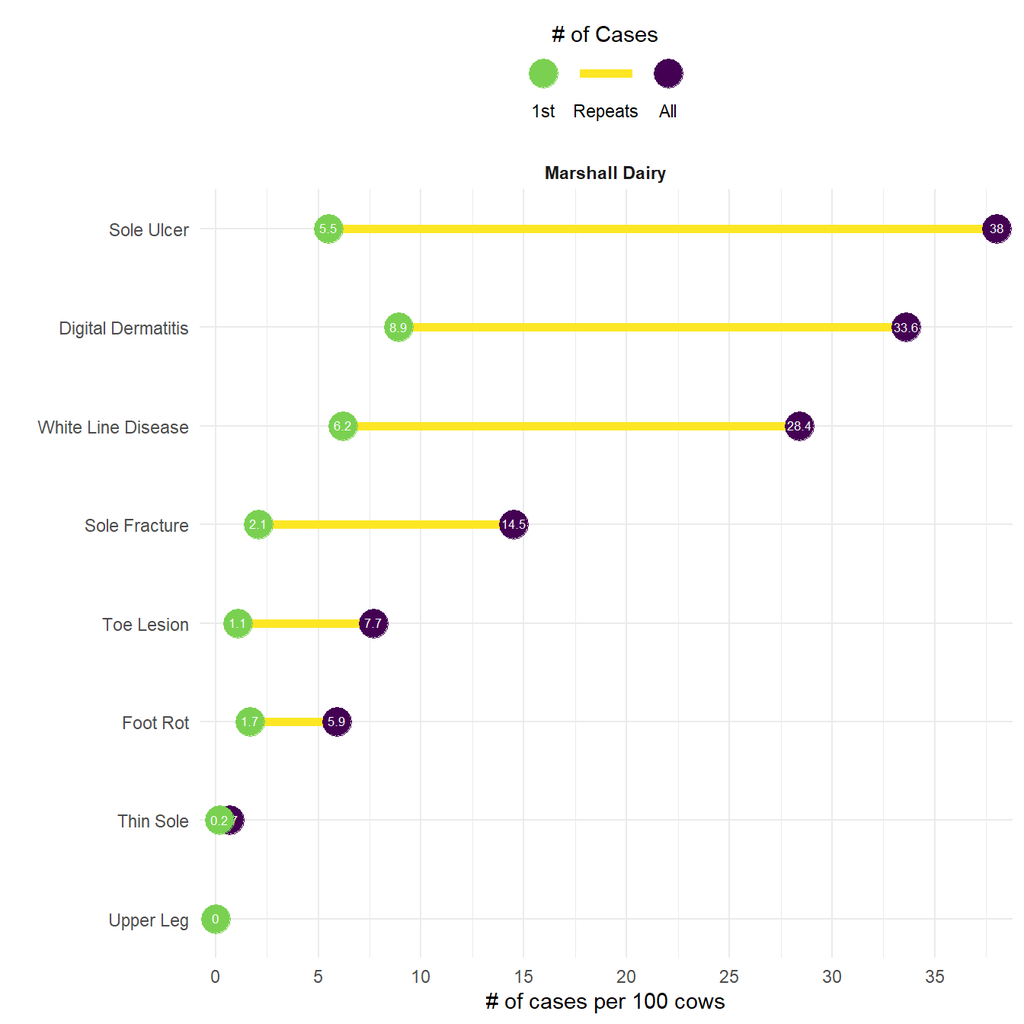

**2024 Infectious Lesions**

Figure 5: Comparision of Infectious lesions

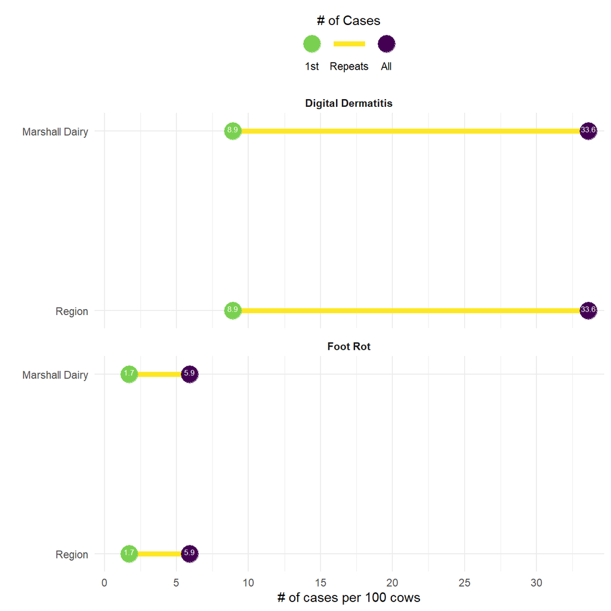

**2024 Non-Infectious**

Figure 6: Comparision of Non-Infectious lesions

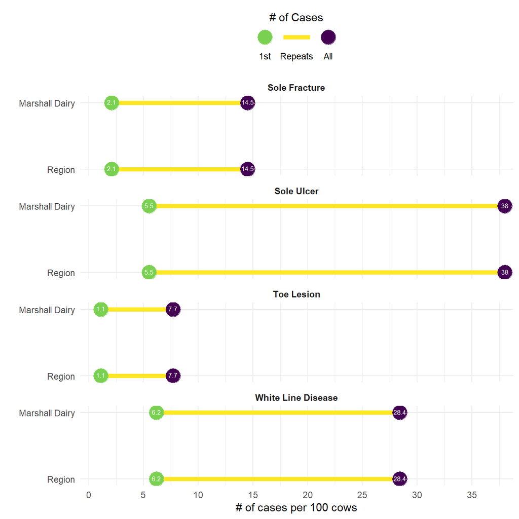

## DIM patterns

The graphs below show the DIM distribution of lesions. Ideally there are no spikes at specific DIM time points. Peaks at 120 and around dry-off suggest that lesions are detected in the chute. Peaks at these time point typically suggest cows are not being found soon enough

**All Lesions**

**Marshall Dairy**

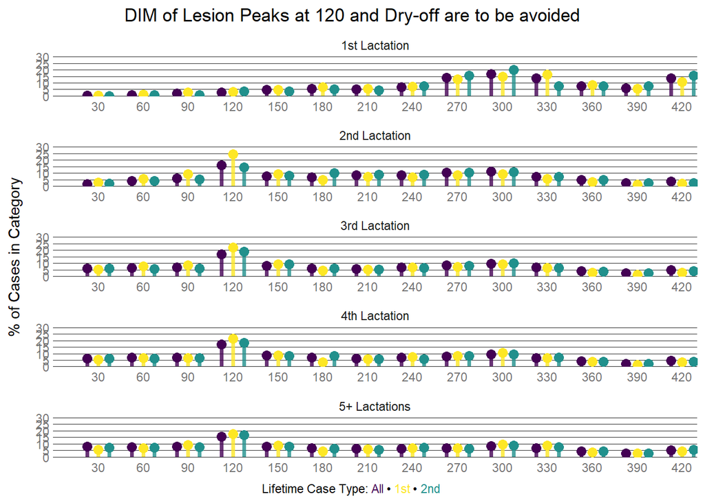

**DD lesions DIM**

**Marshall Dairy**

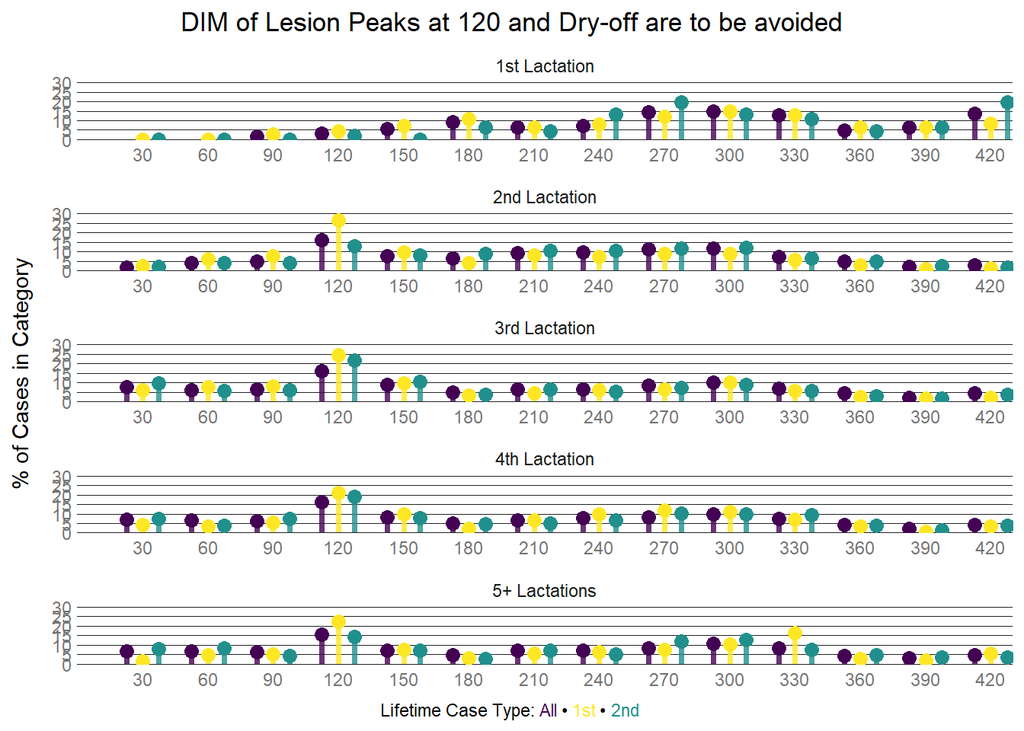

**WLD lesions DIM**

**Marshall Dairy**

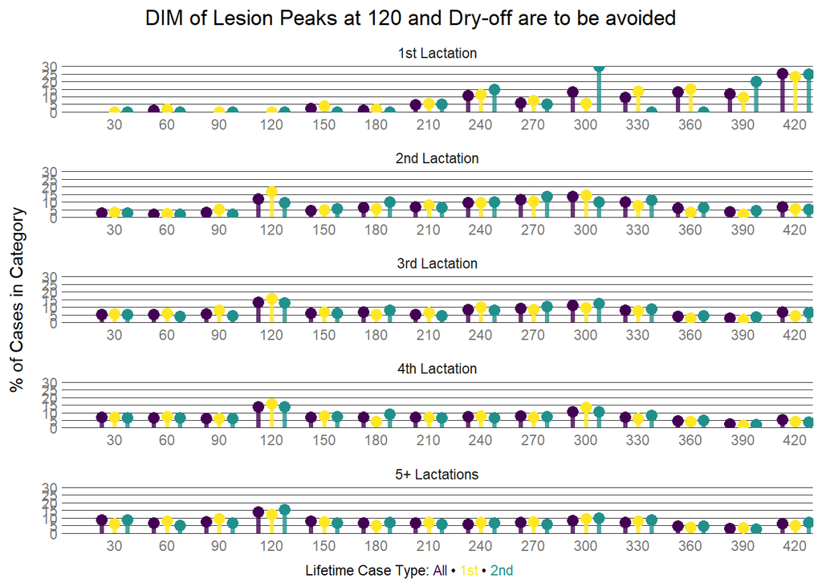

# Impact of Season

These graphs shows the seasonal pattern of non-infectious lesions. Peaks in fall months are typical of heat stress related problems.

## Non-Infectious Lesions

**2024**

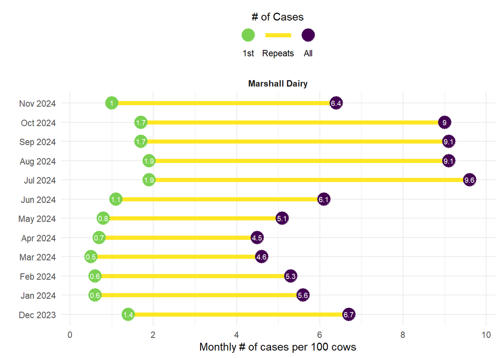

**Previous Year**

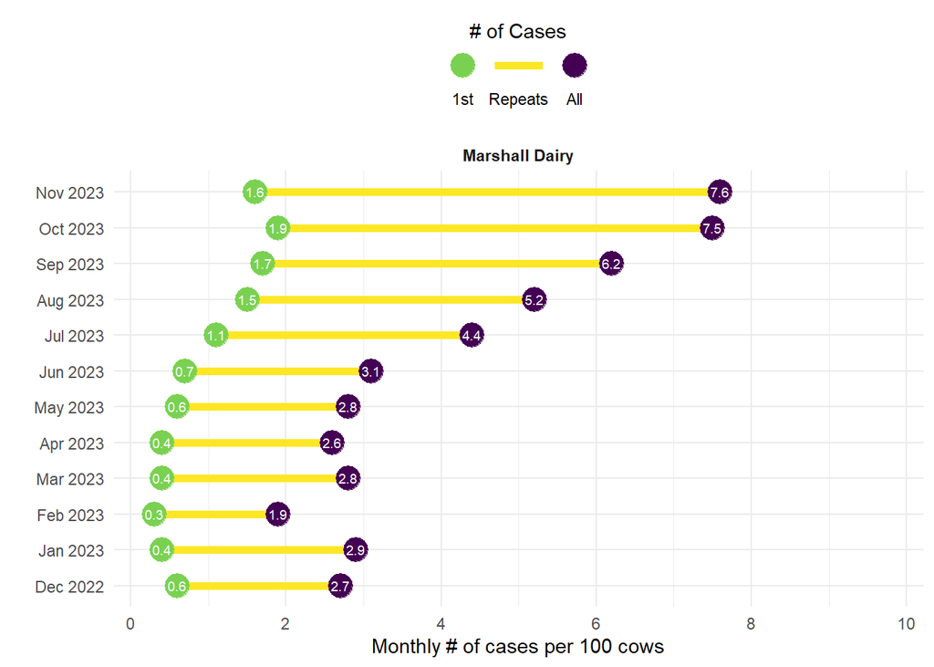

## Infectious Lesions

**2024**

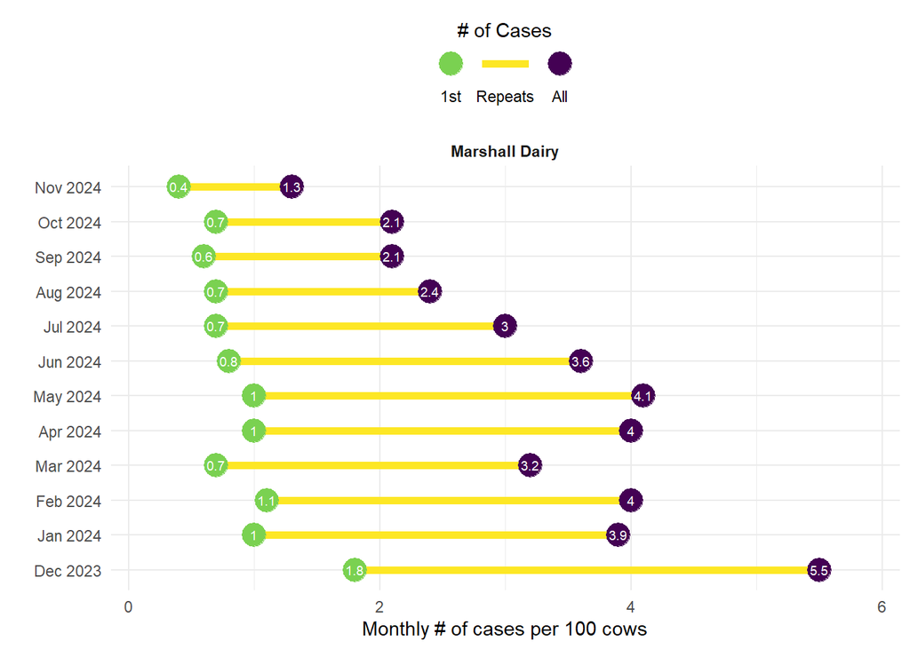

**Previous Year**

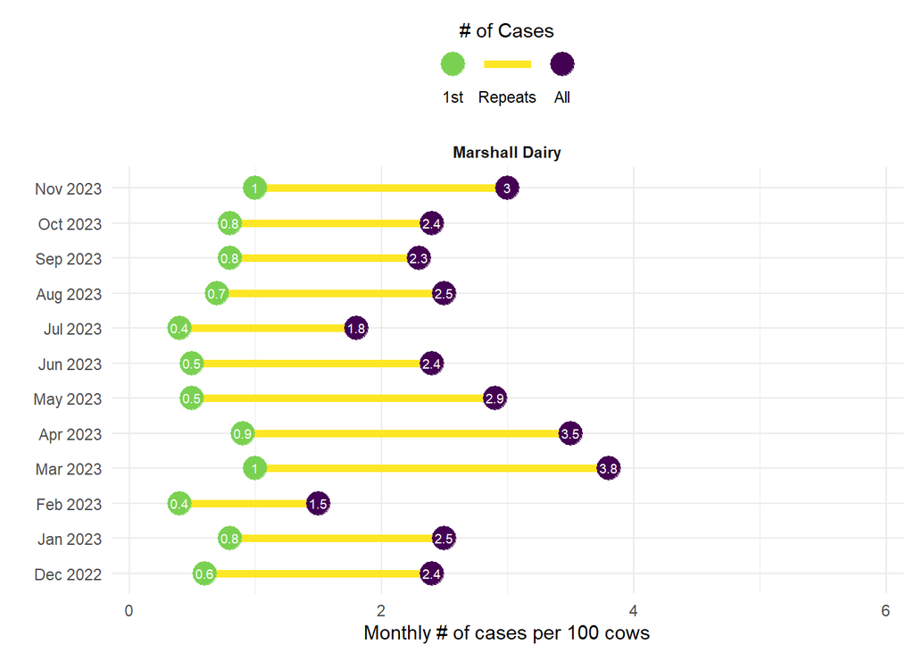

# What is Success of Treatment?

The tables below show the % of cows in the last year that had a lesion and repeated that lesions. This is at the cow level not necessarily repeated on the same leg. Repeats occur because either the cow had a lesion on a different foot or because treatment did not help the cow. A repeat case is considered the next time a cows cows in the chute with the same lesion and time is not accounted for as if it was within a few days or a month later both take us trimmer and chute time.

## Repeat Tables

**1st Case Repeat %**

Table 2: Repeat rate of lesions after 1st case

| Farm | Repeat % DD | Repeat % WLD | Repeat % Sole Ulcer | Repeat % Toe/Thin | Repeat % Footrot |
| --- | --- | --- | --- | --- | --- |
| Marshall Dairy | 34.7 | 31.2 | 29.3 | 27.8 | 43.7 |

**2nd Cases Repeat %**

Table 3: Repeat rate of lesions after 2nd case

| Farm | Repeat % DD | Repeat % WLD | Repeat % Sole Ulcer | Repeat % Toe/Thin | Repeat % Footrot |
| --- | --- | --- | --- | --- | --- |
| Marshall Dairy | 43.8 | 32.4 | 39.4 | 38.4 | 42 |

## Time to Next Lesion

Figure 7 and Table 4 show how soon after having a *non-infectious lesion* cows are back in the chute with another lesion. It is important to look at this as if the repeats happen quickly after treatment, and it suggests thatthe treatment and detection protocol needs to be improved.

Figure 7: The longer and closer the 100% the line the better

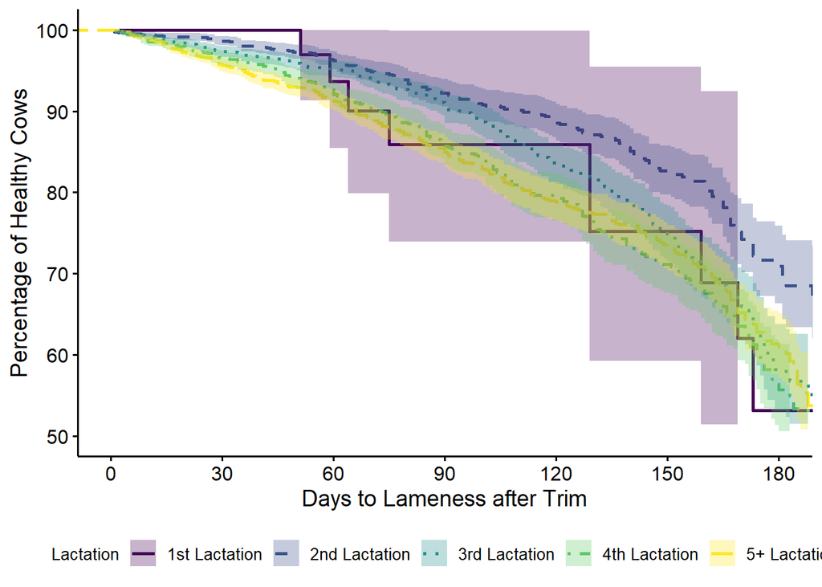

### Table

Table 4: Time to lameness after a cow’s first non infectious lesion at specific time points

| Lactation | % Lame (Confidence Interval) at 7 Days | % Lame (Confidence Interval) at 14 Days | % Lame (Confidence Interval) at 28 Days | % Lame (Confidence Interval) at 90 Days | % Lame (Confidence Interval) at 180 Days |
| --- | --- | --- | --- | --- | --- |
| 1 | 0% (0%, 0%) | 0% (0%, 0%) | 0% (0%, 0%) | 14% (0.1%, 26%) | 47% (15%, 67%) |
| 2 | 0.5% (0.2%, 0.8%) | 0.8% (0.4%, 1.2%) | 1.3% (0.7%, 1.8%) | 7.8% (6.0%, 9.5%) | 29% (24%, 34%) |
| 3 | 0.6% (0.3%, 0.9%) | 1.2% (0.8%, 1.7%) | 2.5% (1.9%, 3.2%) | 9.8% (8.1%, 11%) | 42% (36%, 47%) |
| 4 | 0.8% (0.4%, 1.2%) | 1.7% (1.1%, 2.3%) | 3.3% (2.4%, 4.1%) | 14% (12%, 17%) | 44% (39%, 49%) |
| 5+ | 0.8% (0.5%, 1.1%) | 1.7% (1.2%, 2.2%) | 3.9% (3.1%, 4.7%) | 15% (13%, 17%) | 39% (35%, 43%) |

# Survival of cows after treatment for lesions

The following figures illustrate how quickly after a lesion diagnosis cows are culled (sold/died).

## Non-Infectious Lesions

From Figure 8 it is clear from that cows with lesions get culled faster than cows with no lesions at hoof trimming.

Figure 8: Cows with lesoins get culled faster and survival is worse for each repeated case.

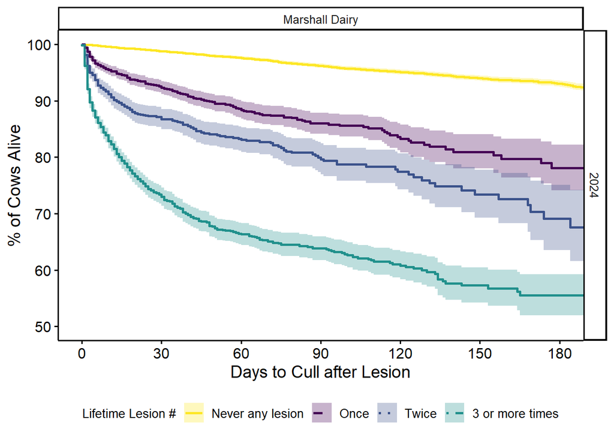

### Tables

**Marshall Dairy**

| Lifetime Lesion History | % Culled (Confidence Interval) at 30 Days | % Culled (Confidence Interval) at 120 Days | % Culled (Confidence Interval) at 180 Days |
| --- | --- | --- | --- |
| Never any lesion | 1.2% (1.0%, 1.4%) | 4.9% (4.5%, 5.3%) | 7.0% (6.4%, 7.5%) |
| Once | 7.7% (6.6%, 8.9%) | 17% (14%, 19%) | 22% (18%, 26%) |
| Twice | 13% (11%, 15%) | 23% (19%, 26%) | 31% (25%, 36%) |
| 3 or more times | 27% (25%, 29%) | 39% (37%, 42%) | 44% (41%, 48%) |

## Infectious Lesions

These graphs shows the impact of infectious lesions on time to culling

Figure 9: Time to cull based for infectious lesions.

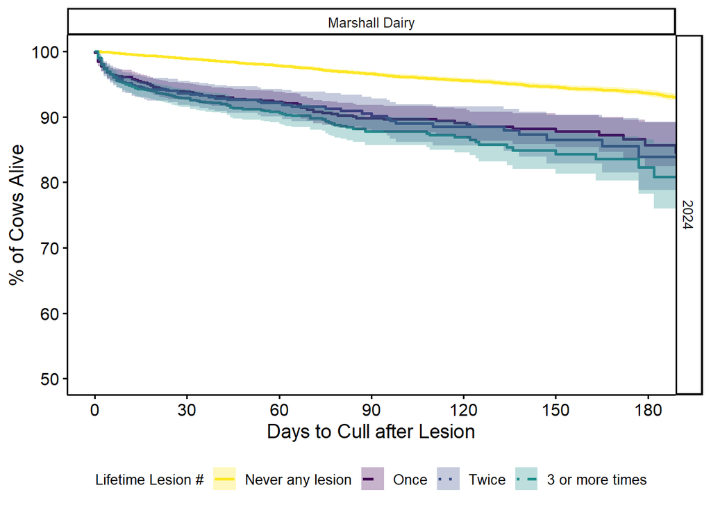

### Tables

**Marshall Dairy**

| Lifetime Lesion History | % Culled (Confidence Interval) at 30 Days | % Culled (Confidence Interval) at 120 Days | % Culled (Confidence Interval) at 180 Days |
| --- | --- | --- | --- |
| Never any lesion | 1.1% (0.9%, 1.3%) | 4.4% (4.1%, 4.8%) | 6.4% (5.9%, 6.8%) |
| Once | 6.2% (4.8%, 7.5%) | 11% (8.8%, 13%) | 14% (11%, 18%) |
| Twice | 6.4% (4.5%, 8.2%) | 11% (8.4%, 14%) | 16% (11%, 21%) |
| 3 or more times | 7.1% (5.7%, 8.5%) | 13% (11%, 15%) | 18% (13%, 22%) |